# The Metropolitan Transportation Authority of New York City

Anthony Josue Roman

*Source file* ⇒ index.Rmd

I will begin analysing the data provided from New York City’s transportation authority, also known as the MTA. The following data used will include success and failure rates for each department.  
In order to use this data, I had to apply through its website in order to obtain this data. The given data will be provided along with this file, and in the website. In order to make this data easier to read, there were csv files created in order to yield a viable graph and for data wrangling purposes.

New York City is one of the most populated cities in the world, and has one of the largest public transportation systems in the world as well.

```
## [1] "agency.txt"         "calendar_dates.txt" "calendar.txt"
## [4] "routes.txt"         "shapes.txt"         "stop_times.txt"
## [7] "stops.txt"          "transfers.txt"      "trips.txt"
```

[interactive chart not shown]

## New York City Bus

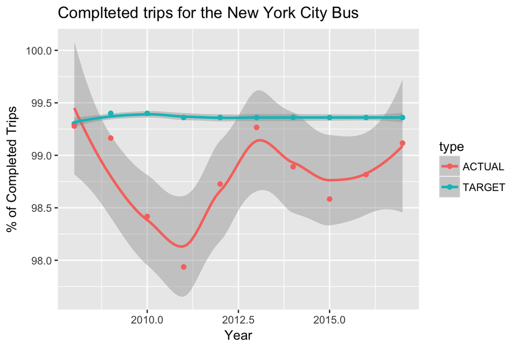

Below is the data used for the graph above, which explains the completed trip percentage per year. The type shows the difference between the actual and target (predicted) data gathered for NYCT Bus.

| INDICATOR_NAME | PERIOD_YEAR | count | type |
| --- | --- | --- | --- |
| % of Completed Trips - NYCT Bus | 2008 | 99.30000 | TARGET |
| % of Completed Trips - NYCT Bus | 2008 | 99.27833 | ACTUAL |
| % of Completed Trips - NYCT Bus | 2009 | 99.40000 | TARGET |
| % of Completed Trips - NYCT Bus | 2009 | 99.16417 | ACTUAL |
| % of Completed Trips - NYCT Bus | 2010 | 99.40000 | TARGET |
| % of Completed Trips - NYCT Bus | 2010 | 98.41750 | ACTUAL |
| % of Completed Trips - NYCT Bus | 2011 | 99.36000 | TARGET |
| % of Completed Trips - NYCT Bus | 2011 | 97.93667 | ACTUAL |
| % of Completed Trips - NYCT Bus | 2012 | 99.36000 | TARGET |
| % of Completed Trips - NYCT Bus | 2012 | 98.72667 | ACTUAL |
| % of Completed Trips - NYCT Bus | 2013 | 99.36000 | TARGET |
| % of Completed Trips - NYCT Bus | 2013 | 99.26583 | ACTUAL |
| % of Completed Trips - NYCT Bus | 2014 | 99.36000 | TARGET |
| % of Completed Trips - NYCT Bus | 2014 | 98.89083 | ACTUAL |
| % of Completed Trips - NYCT Bus | 2015 | 99.36000 | TARGET |
| % of Completed Trips - NYCT Bus | 2015 | 98.58333 | ACTUAL |
| % of Completed Trips - NYCT Bus | 2016 | 99.36000 | TARGET |
| % of Completed Trips - NYCT Bus | 2016 | 98.81667 | ACTUAL |
| % of Completed Trips - NYCT Bus | 2017 | 99.36000 | TARGET |
| % of Completed Trips - NYCT Bus | 2017 | 99.11625 | ACTUAL |

## Metro North Railroad

This is the Metro North Railroad with multiple indicator types, and I will focus on the MNRR Hudson Harlem and Port Jervis Lines.

| INDICATOR_NAME | PERIOD_YEAR | avgtarget | avgactual |
| --- | --- | --- | --- |
| Harlem Line - OTP | 2008 | 98.000 | 98.53333 |
| Harlem Line - OTP | 2009 | 98.200 | 98.52500 |
| Harlem Line - OTP | 2010 | 98.300 | 98.70833 |
| Harlem Line - OTP | 2011 | 98.300 | 97.61667 |
| Harlem Line - OTP | 2012 | 98.300 | 98.50000 |
| Harlem Line - OTP | 2013 | 98.300 | 97.35833 |
| Harlem Line - OTP | 2014 | 94.000 | 93.23333 |
| Harlem Line - OTP | 2015 | 93.000 | 93.08333 |
| Harlem Line - OTP | 2016 | 93.000 | 94.87500 |
| Harlem Line - OTP | 2017 | 93.000 | 95.87778 |
| Hudson Line - OTP | 2008 | 98.000 | 98.11667 |
| Hudson Line - OTP | 2009 | 97.900 | 97.82500 |
| Hudson Line - OTP | 2010 | 98.100 | 98.25833 |
| Hudson Line - OTP | 2011 | 98.200 | 97.92500 |
| Hudson Line - OTP | 2012 | 98.200 | 98.46667 |
| Hudson Line - OTP | 2013 | 98.200 | 97.70000 |
| Hudson Line - OTP | 2014 | 94.000 | 91.48333 |
| Hudson Line - OTP | 2015 | 93.000 | 93.73333 |
| Hudson Line - OTP | 2016 | 93.000 | 95.25833 |
| Hudson Line - OTP | 2017 | 93.000 | 95.82222 |
| New Haven Line - OTP | 2008 | 97.100 | 97.64167 |
| New Haven Line - OTP | 2009 | 97.000 | 96.72500 |
| New Haven Line - OTP | 2010 | 97.000 | 97.20000 |
| New Haven Line - OTP | 2011 | 97.200 | 93.86667 |
| New Haven Line - OTP | 2012 | 97.200 | 97.70833 |
| New Haven Line - OTP | 2013 | 97.200 | 94.75833 |
| New Haven Line - OTP | 2014 | 92.000 | 88.47500 |
| New Haven Line - OTP | 2015 | 93.000 | 90.83333 |
| New Haven Line - OTP | 2016 | 93.000 | 93.10833 |
| New Haven Line - OTP | 2017 | 93.000 | 93.88889 |
| Pascack Valley Line - OTP | 2008 | 95.600 | 96.86667 |
| Pascack Valley Line - OTP | 2009 | 97.000 | 95.59167 |
| Pascack Valley Line - OTP | 2010 | 97.000 | 97.77500 |
| Pascack Valley Line - OTP | 2011 | 97.000 | 97.06667 |
| Pascack Valley Line - OTP | 2012 | 97.000 | 98.28333 |
| Pascack Valley Line - OTP | 2013 | 97.450 | 97.35833 |
| Pascack Valley Line - OTP | 2014 | 97.600 | 94.85833 |
| Pascack Valley Line - OTP | 2015 | 96.500 | 94.15000 |
| Pascack Valley Line - OTP | 2016 | 96.500 | 96.97500 |
| Pascack Valley Line - OTP | 2017 | 96.500 | 96.12222 |
| Port Jervis Line - OTP | 2008 | 94.400 | 95.40833 |
| Port Jervis Line - OTP | 2009 | 95.000 | 95.94167 |
| Port Jervis Line - OTP | 2010 | 95.200 | 95.08333 |
| Port Jervis Line - OTP | 2011 | 95.500 | 92.85000 |
| Port Jervis Line - OTP | 2012 | 95.500 | 96.13333 |
| Port Jervis Line - OTP | 2013 | 96.025 | 96.30833 |
| Port Jervis Line - OTP | 2014 | 96.200 | 93.45000 |
| Port Jervis Line - OTP | 2015 | 95.000 | 93.45000 |
| Port Jervis Line - OTP | 2016 | 95.000 | 95.87500 |
| Port Jervis Line - OTP | 2017 | 95.000 | 92.47778 |

### Hudson Line

Below is the Metro North Hudson line, where we will analyse the data on the percentage that the trains arrive on time.

| PERIOD_YEAR | avgtarget | avgactual |
| --- | --- | --- |
| 2008 | 98.0 | 98.11667 |
| 2009 | 97.9 | 97.82500 |
| 2010 | 98.1 | 98.25833 |
| 2011 | 98.2 | 97.92500 |
| 2012 | 98.2 | 98.46667 |
| 2013 | 98.2 | 97.70000 |
| 2014 | 94.0 | 91.48333 |
| 2015 | 93.0 | 93.73333 |
| 2016 | 93.0 | 95.25833 |
| 2017 | 93.0 | 95.82222 |

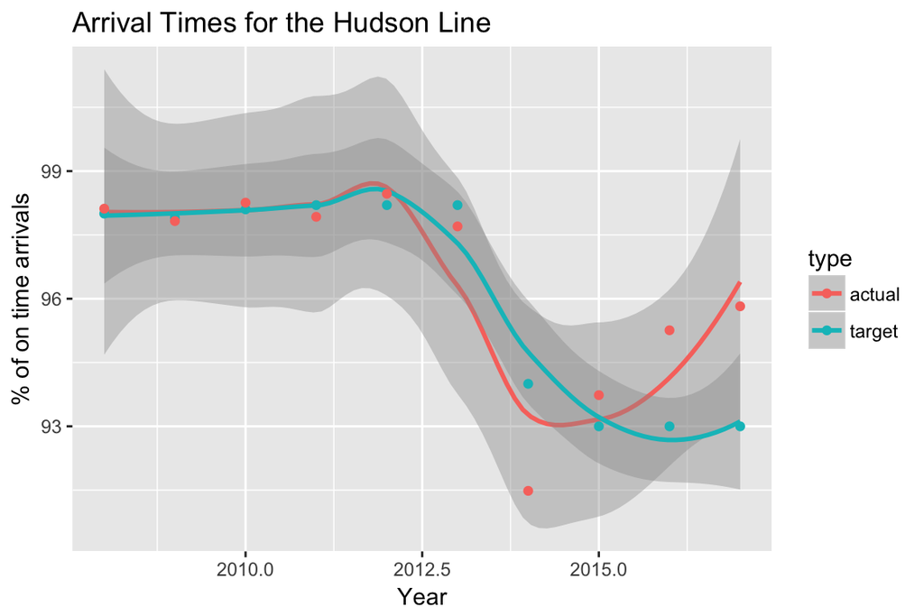

### Port Jervis Line

Below is the Port Jervis line, where we will analyse the data on the percentage that the trains arrive on time along with its graph.

| PERIOD_YEAR | avgtarget | avgactual |
| --- | --- | --- |
| 2008 | 94.400 | 95.40833 |
| 2009 | 95.000 | 95.94167 |
| 2010 | 95.200 | 95.08333 |
| 2011 | 95.500 | 92.85000 |
| 2012 | 95.500 | 96.13333 |
| 2013 | 96.025 | 96.30833 |
| 2014 | 96.200 | 93.45000 |
| 2015 | 95.000 | 93.45000 |
| 2016 | 95.000 | 95.87500 |
| 2017 | 95.000 | 92.47778 |

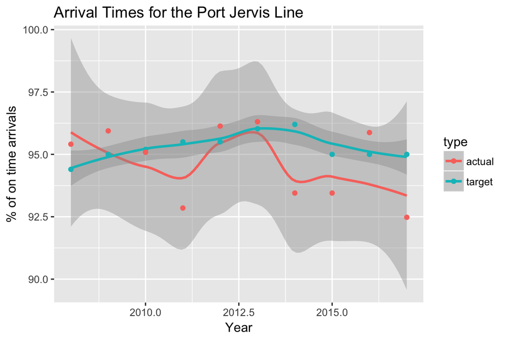

### New Haven Line

Below is the New Haven line, where we will analyse the data on the percentage that the trains arrive on time along with its graph.

| PERIOD_YEAR | avgtarget | avgactual |
| --- | --- | --- |
| 2008 | 97.1 | 97.64167 |
| 2009 | 97.0 | 96.72500 |
| 2010 | 97.0 | 97.20000 |
| 2011 | 97.2 | 93.86667 |
| 2012 | 97.2 | 97.70833 |
| 2013 | 97.2 | 94.75833 |
| 2014 | 92.0 | 88.47500 |
| 2015 | 93.0 | 90.83333 |
| 2016 | 93.0 | 93.10833 |
| 2017 | 93.0 | 93.88889 |

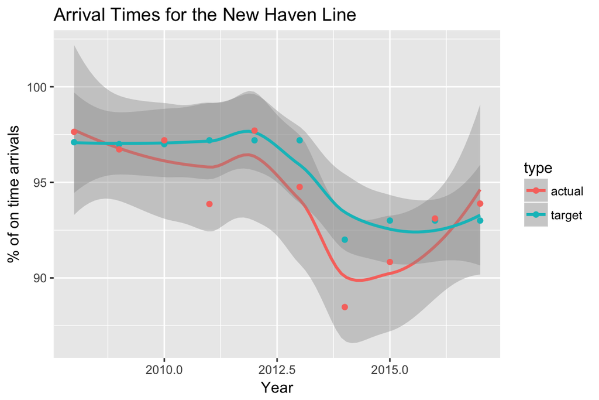

### Harlem Line

Below is the Harlem line, where we will analyse the data on the percentage that the trains arrive on time along with its graph.

| PERIOD_YEAR | avgtarget | avgactual |
| --- | --- | --- |
| 2008 | 98.0 | 98.53333 |
| 2009 | 98.2 | 98.52500 |
| 2010 | 98.3 | 98.70833 |
| 2011 | 98.3 | 97.61667 |
| 2012 | 98.3 | 98.50000 |
| 2013 | 98.3 | 97.35833 |
| 2014 | 94.0 | 93.23333 |
| 2015 | 93.0 | 93.08333 |
| 2016 | 93.0 | 94.87500 |
| 2017 | 93.0 | 95.87778 |

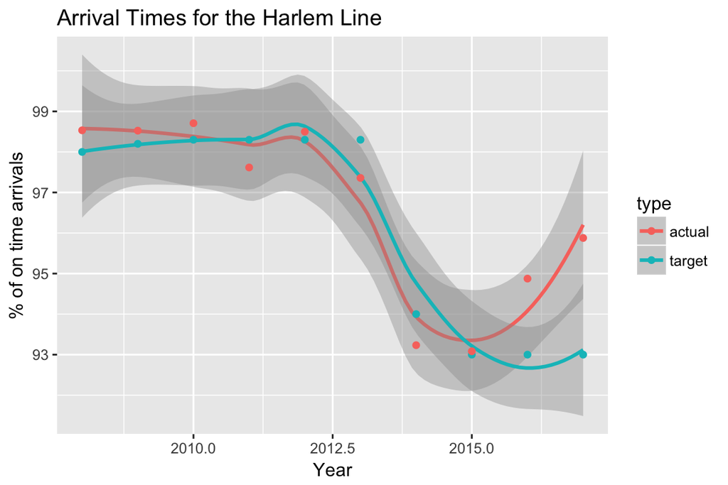

### Pascack Valley Line

Below is the Pascack Valley line, where we will analyse the data on the percentage that the trains arrive on time along with its graph.

| PERIOD_YEAR | avgtarget | avgactual |
| --- | --- | --- |
| 2008 | 95.60 | 96.86667 |
| 2009 | 97.00 | 95.59167 |
| 2010 | 97.00 | 97.77500 |
| 2011 | 97.00 | 97.06667 |
| 2012 | 97.00 | 98.28333 |
| 2013 | 97.45 | 97.35833 |
| 2014 | 97.60 | 94.85833 |
| 2015 | 96.50 | 94.15000 |
| 2016 | 96.50 | 96.97500 |
| 2017 | 96.50 | 96.12222 |

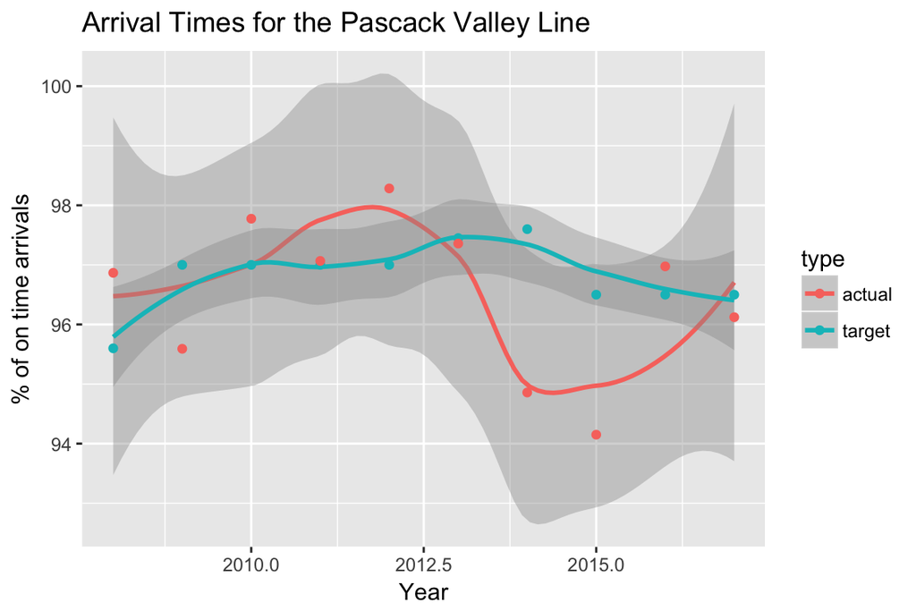

### MNRR Trunk Lines

Below shows the comparisons between all the MNRR trunk line actual and target arrival times, with each indicator name being the name of the MNRR trunk line.

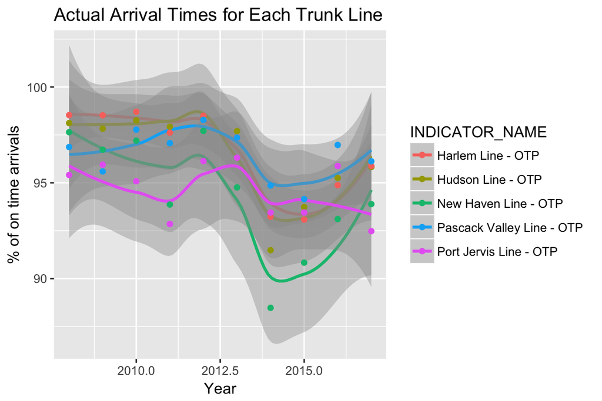

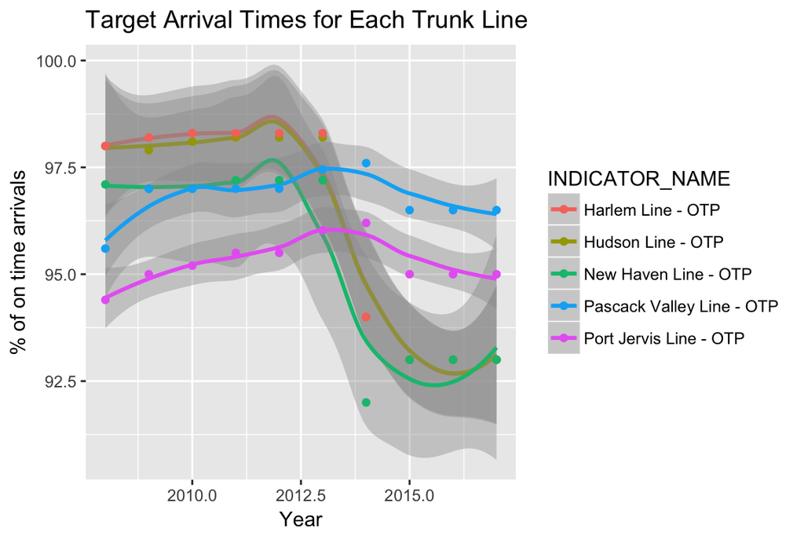

## Total Ridership

| PERIOD_YEAR | avgtarget | avgactual |
| --- | --- | --- |
| 2008 | 43484481 | 44694354 |
| 2009 | 45432199 | 42744538 |
| 2010 | 41864369 | 42987958 |
| 2011 | 43289693 | 43446730 |
| 2012 | 44470349 | 44900280 |
| 2013 | 45988267 | 44673620 |
| 2014 | 45607142 | 44890429 |
| 2015 | 45718093 | 45430540 |
| 2016 | 46392773 | 46100736 |
| 2017 | 31949881 | 31452622 |

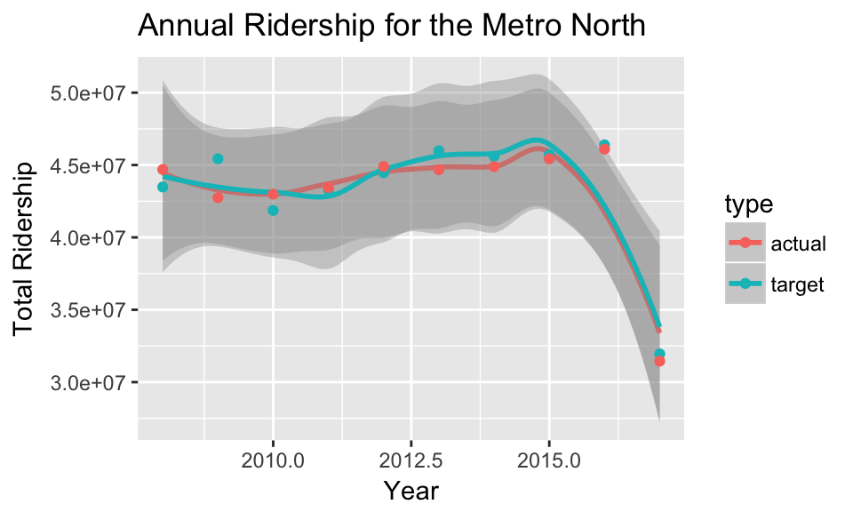